# 기말고사대체과제[32164420-조정민]

## 전국 신규 민간 아파트 분양가격 분석

전국의 신규 민간 아파트의 분양가격을 분석하도록 하겠다.

```python
import warnings
warnings.filterwarnings('ignore')
import numpy as np
import pandas as pd
import re
import matplotlib.pyplot as plt
import seaborn as sns
from matplotlib import font_manager, rc
font_path = 'C:/Windows/Fonts/H2GTRE.TTF'
font = font_manager.FontProperties(fname=font_path).get_name()
rc('font', family=font)
```

```python
df = pd.read_csv("주택도시보증공사_전국 신규 민간 아파트 분양가격 동향_20200331.csv", engine='python')
df.shape
```

```
(4590, 5)
```

```python
df.head()
```

|  | 지역명 | 규모구분 | 연도 | 월 | 분양가격(㎡) |
| --- | --- | --- | --- | --- | --- |
| 0 | 서울 | 전체 | 2015 | 10 | 5841 |
| 1 | 서울 | 전용면적 60㎡이하 | 2015 | 10 | 5652 |
| 2 | 서울 | 전용면적 60㎡초과 85㎡이하 | 2015 | 10 | 5882 |
| 3 | 서울 | 전용면적 85㎡초과 102㎡이하 | 2015 | 10 | 5721 |
| 4 | 서울 | 전용면적 102㎡초과 | 2015 | 10 | 5879 |

```python
df.tail()
```

|  | 지역명 | 규모구분 | 연도 | 월 | 분양가격(㎡) |
| --- | --- | --- | --- | --- | --- |
| 4585 | 제주 | 전체 | 2020 | 3 | 3955 |
| 4586 | 제주 | 전용면적 60㎡이하 | 2020 | 3 | 4039 |
| 4587 | 제주 | 전용면적 60㎡초과 85㎡이하 | 2020 | 3 | 3962 |
| 4588 | 제주 | 전용면적 85㎡초과 102㎡이하 | 2020 | 3 | NaN |
| 4589 | 제주 | 전용면적 102㎡초과 | 2020 | 3 | 3601 |

```python
df.info()
```

```
<class 'pandas.core.frame.DataFrame'>
RangeIndex: 4590 entries, 0 to 4589
Data columns (total 5 columns):
 #   Column   Non-Null Count  Dtype
---  ------   --------------  -----
 0   지역명      4590 non-null   object
 1   규모구분     4590 non-null   object
 2   연도       4590 non-null   int64
 3   월        4590 non-null   int64
 4   분양가격(㎡)  4276 non-null   object
dtypes: int64(2), object(3)
memory usage: 179.4+ KB
```

```python
df.isnull().sum()
```

```
지역명          0
규모구분         0
연도           0
월            0
분양가격(㎡)    314
dtype: int64
```

```python
df.isna().sum()
```

```
지역명          0
규모구분         0
연도           0
월            0
분양가격(㎡)    314
dtype: int64
```

각 칼럼에 Null값은 분양가격에만 존재한다. isnull().sum()을 이용해 Null 값을 체크해줬다. True는 1, False는 0이다. isnull() 메소드를 사용하면 null이냐 아니냐에 따라 Ture, False 값이 나타나고 이를 sum해주면 true값들만 컬럼을 기준으로 다 더한다. 314개의 true값이 있음을 확인할 수 있다.

```python
pd.to_numeric(df["분양가격(㎡)"], errors='coerce')
```

```
0       5841.0
1       5652.0
2       5882.0
3       5721.0
4       5879.0
         ...
4585    3955.0
4586    4039.0
4587    3962.0
4588       NaN
4589    3601.0
Name: 분양가격(㎡), Length: 4590, dtype: float64
```

```python
df["분양가격"] = pd.to_numeric(df["분양가격(㎡)"], errors='coerce')
df["분양가격"].head(1)
```

```
0    5841.0
Name: 분양가격, dtype: float64
```

```python
type(pd.np.nan)
```

```
float
```

to_numeric에서 errors 옵션을 사용했다. coerce의 경우는 무시하고 공백도 인트로 바꿔준다. 위 결과에서는 nan값이 float타입이기 때문에 전체가 float형태로 바뀌었다.

```python
df.info()
```

```
<class 'pandas.core.frame.DataFrame'>
RangeIndex: 4590 entries, 0 to 4589
Data columns (total 6 columns):
 #   Column   Non-Null Count  Dtype
---  ------   --------------  -----
 0   지역명      4590 non-null   object
 1   규모구분     4590 non-null   object
 2   연도       4590 non-null   int64
 3   월        4590 non-null   int64
 4   분양가격(㎡)  4276 non-null   object
 5   분양가격     4260 non-null   float64
dtypes: float64(1), int64(2), object(3)
memory usage: 215.3+ KB
```

```python
# 오브젝트 타입의 요약
df["분양가격(㎡)"].describe()
```

```
count     4276
unique    1766
top       3395
freq        18
Name: 분양가격(㎡), dtype: object
```

```python
# 수치데이터로 변경된 분양가격 컬럼 요약
df["분양가격"].describe()
```

```
count     4260.000000
mean      3270.160798
std       1300.362742
min       1868.000000
25%       2454.750000
50%       2890.000000
75%       3601.000000
max      13835.000000
Name: 분양가격, dtype: float64
```

```python
df["규모구분"].unique()
```

```
array(['전체', '전용면적 60㎡이하', '전용면적 60㎡초과 85㎡이하', '전용면적 85㎡초과 102㎡이하',
       '전용면적 102㎡초과'], dtype=object)
```

```python
df["전용면적"] = df["규모구분"].str.replace("전용면적", "")
#df["규모구분"].str.replace("초과", "")
df["전용면적"]
```

```
0                  전체
1               60㎡이하
2         60㎡초과 85㎡이하
3        85㎡초과 102㎡이하
4              102㎡초과
            ...
4585               전체
4586            60㎡이하
4587      60㎡초과 85㎡이하
4588     85㎡초과 102㎡이하
4589           102㎡초과
Name: 전용면적, Length: 4590, dtype: object
```

```python
df["전용면적"] = df["규모구분"].str.replace("전용면적", "")
df["전용면적"] = df["전용면적"].str.replace("초과", "~")
df["전용면적"] = df["전용면적"].str.replace("이하", "")
df["전용면적"] = df["전용면적"].str.replace(" ", "").str.strip()
df["전용면적"]
```

```
0             전체
1            60㎡
2        60㎡~85㎡
3       85㎡~102㎡
4          102㎡~
          ...
4585          전체
4586         60㎡
4587     60㎡~85㎡
4588    85㎡~102㎡
4589       102㎡~
Name: 전용면적, Length: 4590, dtype: object
```

전용면적의 데이터 값을 보기 좋은 문자열로 replace해줬다.

```python
df.info()
```

```
<class 'pandas.core.frame.DataFrame'>
RangeIndex: 4590 entries, 0 to 4589
Data columns (total 7 columns):
 #   Column   Non-Null Count  Dtype
---  ------   --------------  -----
 0   지역명      4590 non-null   object
 1   규모구분     4590 non-null   object
 2   연도       4590 non-null   int64
 3   월        4590 non-null   int64
 4   분양가격(㎡)  4276 non-null   object
 5   분양가격     4260 non-null   float64
 6   전용면적     4590 non-null   object
dtypes: float64(1), int64(2), object(4)
memory usage: 251.1+ KB
```

```python
# axis 0: 행, 1: 열
df = df.drop(["규모구분", "분양가격(㎡)"], axis=1)
df.head(1)
```

|  | 지역명 | 연도 | 월 | 분양가격 | 전용면적 |
| --- | --- | --- | --- | --- | --- |
| 0 | 서울 | 2015 | 10 | 5841.0 | 전체 |

불필요한 컬럼(규모구분, 분양가격(㎡))을 제거했다.

```python
df
```

|  | 지역명 | 연도 | 월 | 분양가격 | 전용면적 |
| --- | --- | --- | --- | --- | --- |
| 0 | 서울 | 2015 | 10 | 5841.0 | 전체 |
| 1 | 서울 | 2015 | 10 | 5652.0 | 60㎡ |
| 2 | 서울 | 2015 | 10 | 5882.0 | 60㎡~85㎡ |
| 3 | 서울 | 2015 | 10 | 5721.0 | 85㎡~102㎡ |
| 4 | 서울 | 2015 | 10 | 5879.0 | 102㎡~ |
| ... | ... | ... | ... | ... | ... |
| 4585 | 제주 | 2020 | 3 | 3955.0 | 전체 |
| 4586 | 제주 | 2020 | 3 | 4039.0 | 60㎡ |
| 4587 | 제주 | 2020 | 3 | 3962.0 | 60㎡~85㎡ |
| 4588 | 제주 | 2020 | 3 | NaN | 85㎡~102㎡ |
| 4589 | 제주 | 2020 | 3 | 3601.0 | 102㎡~ |

4590 rows × 5 columns

```python
df.groupby(["지역명"])["분양가격"].mean()
```

```
지역명
강원    2419.072797
경기    4087.385185
경남    2817.060606
경북    2548.451362
광주    3066.281106
대구    3679.222222
대전    3132.873239
부산    3687.429630
서울    7268.218519
세종    2993.287402
울산    3046.746914
인천    3645.875940
전남    2316.270677
전북    2352.917603
제주    3440.598291
충남    2506.089147
충북    2320.633333
Name: 분양가격, dtype: float64
```

```python
df.groupby(["전용면적"])["분양가격"].mean()
```

```
전용면적
102㎡~       3524.597619
60㎡         3172.022196
60㎡~85㎡     3137.927393
85㎡~102㎡    3414.938338
전체          3140.871287
Name: 분양가격, dtype: float64
```

```python
df.groupby(["지역명", "전용면적"])["분양가격"].mean()
```

```
지역명  전용면적
강원   102㎡~       2599.703704
     60㎡         2306.148148
     60㎡~85㎡     2280.185185
     85㎡~102㎡    2671.977778
     전체          2279.500000
                    ...
충북   102㎡~       2490.666667
     60㎡         2166.481481
     60㎡~85㎡     2207.685185
     85㎡~102㎡    2542.851852
     전체          2195.481481
Name: 분양가격, Length: 85, dtype: float64
```

```python
df.groupby(["전용면적", "지역명"])["분양가격"].mean().unstack()
```

| 지역명 전용면적 | 강원 | 경기 | 경남 | 경북 | 광주 | 대구 | 대전 | 부산 | 서울 | 세종 | 울산 | 인천 | 전남 | 전북 | 제주 | 충남 | 충북 |
| --- | --- | --- | --- | --- | --- | --- | --- | --- | --- | --- | --- | --- | --- | --- | --- | --- | --- |
| 102㎡~ | 2599.703704 | 4506.000000 | 3132.880000 | 2790.759259 | 3404.731707 | 4026.314815 | 4507.600000 | 4018.037037 | 7203.259259 | 3106.314815 | 3012.500000 | 4394.620000 | 2519.518519 | 2492.351852 | 3213.460000 | 2637.905660 | 2490.666667 |
| 60㎡ | 2306.148148 | 4060.370370 | 2643.230769 | 2399.685185 | 2921.510204 | 3668.129630 | 2826.000000 | 3463.092593 | 7105.481481 | 2823.710526 | 2847.515152 | 3438.685185 | 2210.407407 | 2317.388889 | 4261.071429 | 2396.851852 | 2166.481481 |
| 60㎡~85㎡ | 2280.185185 | 3823.333333 | 2634.592593 | 2457.111111 | 3048.759259 | 3619.462963 | 2971.000000 | 3617.796296 | 6955.351852 | 2981.870370 | 3182.355556 | 3484.629630 | 2223.425926 | 2217.370370 | 3264.666667 | 2382.574074 | 2207.685185 |
| 85㎡~102㎡ | 2671.977778 | 4207.685185 | 3045.129630 | 2658.731707 | 2817.000000 | 3421.711111 | 2750.777778 | 3700.648148 | 8162.925926 | 3009.833333 | 2685.153846 | 3518.574074 | 2406.680000 | 2522.882353 | 3245.176471 | 2794.162791 | 2542.851852 |
| 전체 | 2279.500000 | 3839.537037 | 2646.425926 | 2462.518519 | 3045.907407 | 3617.574074 | 2994.833333 | 3637.574074 | 6914.074074 | 2994.462963 | 3181.488889 | 3448.333333 | 2228.018519 | 2224.037037 | 3311.740741 | 2380.074074 | 2195.481481 |

```python
# 연도, 지역명으로 분양가격의 평균을 구한다.
g = df.groupby(["연도", "지역명"])["분양가격"].mean()
g
```

```
연도    지역명
2015  강원     2178.200000
      경기     3351.800000
      경남     2563.400000
      경북     2261.866667
      광주     2399.000000
                ...
2020  전남     2744.538462
      전북     2576.600000
      제주     3889.250000
      충남     2736.000000
      충북     2470.466667
Name: 분양가격, Length: 102, dtype: float64
```

```python
df.groupby(["연도", "지역명"])["분양가격"].mean().unstack()
```

| 지역명 연도 | 강원 | 경기 | 경남 | 경북 | 광주 | 대구 | 대전 | 부산 | 서울 | 세종 | 울산 | 인천 | 전남 | 전북 | 제주 | 충남 | 충북 |
| --- | --- | --- | --- | --- | --- | --- | --- | --- | --- | --- | --- | --- | --- | --- | --- | --- | --- |
| 2015 | 2178.200000 | 3351.800000 | 2563.400000 | 2261.866667 | 2399.000000 | 2733.000000 | 2482.000000 | 3144.666667 | 6156.266667 | 2656.066667 | 2838.666667 | 3326.066667 | 2060.266667 | 2154.666667 | 2409.416667 | 2330.266667 | 2069.333333 |
| 2016 | 2170.576923 | 3540.900000 | 2574.766667 | 2349.516667 | 2785.055556 | 3115.766667 | 2700.222222 | 3255.616667 | 6591.950000 | 2684.183333 | 2903.810345 | 3363.350000 | 2102.000000 | 2092.916667 | 2899.236364 | 2411.583333 | 2161.616667 |
| 2017 | 2217.833333 | 3726.116667 | 2668.666667 | 2511.534483 | 2909.000000 | 3694.537037 | 3003.912281 | 3526.550000 | 6625.483333 | 2767.559322 | 3221.260870 | 3537.100000 | 2246.433333 | 2244.280702 | 3826.830189 | 2471.913793 | 2261.383333 |
| 2018 | 2490.683333 | 4320.733333 | 2826.566667 | 2630.538462 | 2886.955556 | 3678.561404 | 3101.244444 | 3906.050000 | 7030.983333 | 3133.473684 | 3103.454545 | 3600.464286 | 2402.983333 | 2477.150000 | 3616.960000 | 2485.400000 | 2469.483333 |
| 2019 | 2707.416667 | 4747.133333 | 3241.701754 | 2742.500000 | 3670.204545 | 4267.166667 | 3824.000000 | 4102.383333 | 8571.766667 | 3424.058824 | 3095.833333 | 4015.083333 | 2490.689655 | 2585.533333 | 3584.384615 | 2651.163636 | 2415.416667 |
| 2020 | 2919.928571 | 4881.600000 | 3023.000000 | 2753.833333 | 3985.000000 | 4474.866667 | 3708.818182 | 4066.666667 | 9390.933333 | 3573.500000 | 3218.666667 | 4223.600000 | 2744.538462 | 2576.600000 | 3889.250000 | 2736.000000 | 2470.466667 |

```python
df.groupby(["연도", "지역명"])["분양가격"].mean().unstack().T
```

| 연도 지역명 | 2015 | 2016 | 2017 | 2018 | 2019 | 2020 |
| --- | --- | --- | --- | --- | --- | --- |
| 강원 | 2178.200000 | 2170.576923 | 2217.833333 | 2490.683333 | 2707.416667 | 2919.928571 |
| 경기 | 3351.800000 | 3540.900000 | 3726.116667 | 4320.733333 | 4747.133333 | 4881.600000 |
| 경남 | 2563.400000 | 2574.766667 | 2668.666667 | 2826.566667 | 3241.701754 | 3023.000000 |
| 경북 | 2261.866667 | 2349.516667 | 2511.534483 | 2630.538462 | 2742.500000 | 2753.833333 |
| 광주 | 2399.000000 | 2785.055556 | 2909.000000 | 2886.955556 | 3670.204545 | 3985.000000 |
| 대구 | 2733.000000 | 3115.766667 | 3694.537037 | 3678.561404 | 4267.166667 | 4474.866667 |
| 대전 | 2482.000000 | 2700.222222 | 3003.912281 | 3101.244444 | 3824.000000 | 3708.818182 |
| 부산 | 3144.666667 | 3255.616667 | 3526.550000 | 3906.050000 | 4102.383333 | 4066.666667 |
| 서울 | 6156.266667 | 6591.950000 | 6625.483333 | 7030.983333 | 8571.766667 | 9390.933333 |
| 세종 | 2656.066667 | 2684.183333 | 2767.559322 | 3133.473684 | 3424.058824 | 3573.500000 |
| 울산 | 2838.666667 | 2903.810345 | 3221.260870 | 3103.454545 | 3095.833333 | 3218.666667 |
| 인천 | 3326.066667 | 3363.350000 | 3537.100000 | 3600.464286 | 4015.083333 | 4223.600000 |
| 전남 | 2060.266667 | 2102.000000 | 2246.433333 | 2402.983333 | 2490.689655 | 2744.538462 |
| 전북 | 2154.666667 | 2092.916667 | 2244.280702 | 2477.150000 | 2585.533333 | 2576.600000 |
| 제주 | 2409.416667 | 2899.236364 | 3826.830189 | 3616.960000 | 3584.384615 | 3889.250000 |
| 충남 | 2330.266667 | 2411.583333 | 2471.913793 | 2485.400000 | 2651.163636 | 2736.000000 |
| 충북 | 2069.333333 | 2161.616667 | 2261.383333 | 2469.483333 | 2415.416667 | 2470.466667 |

groupby를 이용해 데이터 집계를 하여 그룹별 분양가격의 평균을 확인했다.

```python
pd.pivot_table(df, index=["지역명"], values=["분양가격"], aggfunc="mean")
```

| 지역명 | 분양가격 |
| --- | --- |
| 강원 | 2419.072797 |
| 경기 | 4087.385185 |
| 경남 | 2817.060606 |
| 경북 | 2548.451362 |
| 광주 | 3066.281106 |
| 대구 | 3679.222222 |
| 대전 | 3132.873239 |
| 부산 | 3687.429630 |
| 서울 | 7268.218519 |
| 세종 | 2993.287402 |
| 울산 | 3046.746914 |
| 인천 | 3645.875940 |
| 전남 | 2316.270677 |
| 전북 | 2352.917603 |
| 제주 | 3440.598291 |
| 충남 | 2506.089147 |
| 충북 | 2320.633333 |

```python
df.groupby(["전용면적"])["분양가격"].mean()
```

```
전용면적
102㎡~       3524.597619
60㎡         3172.022196
60㎡~85㎡     3137.927393
85㎡~102㎡    3414.938338
전체          3140.871287
Name: 분양가격, dtype: float64
```

```python
pd.pivot_table(df, index="전용면적", values="분양가격")
```

| 전용면적 | 분양가격 |
| --- | --- |
| 102㎡~ | 3524.597619 |
| 60㎡ | 3172.022196 |
| 60㎡~85㎡ | 3137.927393 |
| 85㎡~102㎡ | 3414.938338 |
| 전체 | 3140.871287 |

pivot_table은 더 명시적으로 인자를 준다는 것과 결과가 데이터프레임으로 나온다는 점이 다르다. groupby는 시리즈 형태로, pivot_table은 데이터프레임 형태로 결과를 출력한다.

```python
# 지역명, 전용면적으로 분양가격의 평균을 구한다.
df.groupby(["전용면적", "지역명"])["분양가격"].mean().unstack().round()
```

| 지역명 전용면적 | 강원 | 경기 | 경남 | 경북 | 광주 | 대구 | 대전 | 부산 | 서울 | 세종 | 울산 | 인천 | 전남 | 전북 | 제주 | 충남 | 충북 |
| --- | --- | --- | --- | --- | --- | --- | --- | --- | --- | --- | --- | --- | --- | --- | --- | --- | --- |
| 102㎡~ | 2600.0 | 4506.0 | 3133.0 | 2791.0 | 3405.0 | 4026.0 | 4508.0 | 4018.0 | 7203.0 | 3106.0 | 3012.0 | 4395.0 | 2520.0 | 2492.0 | 3213.0 | 2638.0 | 2491.0 |
| 60㎡ | 2306.0 | 4060.0 | 2643.0 | 2400.0 | 2922.0 | 3668.0 | 2826.0 | 3463.0 | 7105.0 | 2824.0 | 2848.0 | 3439.0 | 2210.0 | 2317.0 | 4261.0 | 2397.0 | 2166.0 |
| 60㎡~85㎡ | 2280.0 | 3823.0 | 2635.0 | 2457.0 | 3049.0 | 3619.0 | 2971.0 | 3618.0 | 6955.0 | 2982.0 | 3182.0 | 3485.0 | 2223.0 | 2217.0 | 3265.0 | 2383.0 | 2208.0 |
| 85㎡~102㎡ | 2672.0 | 4208.0 | 3045.0 | 2659.0 | 2817.0 | 3422.0 | 2751.0 | 3701.0 | 8163.0 | 3010.0 | 2685.0 | 3519.0 | 2407.0 | 2523.0 | 3245.0 | 2794.0 | 2543.0 |
| 전체 | 2280.0 | 3840.0 | 2646.0 | 2463.0 | 3046.0 | 3618.0 | 2995.0 | 3638.0 | 6914.0 | 2994.0 | 3181.0 | 3448.0 | 2228.0 | 2224.0 | 3312.0 | 2380.0 | 2195.0 |

```python
df.pivot_table(index=["전용면적", "지역명"], values="분양가격")
```

| 전용면적 | 지역명 | 분양가격 |
| --- | --- | --- |
| 102㎡~ | 강원 | 2599.703704 |
|  | 경기 | 4506.000000 |
|  | 경남 | 3132.880000 |
|  | 경북 | 2790.759259 |
|  | 광주 | 3404.731707 |
| ... | ... | ... |
| 전체 | 전남 | 2228.018519 |
|  | 전북 | 2224.037037 |
|  | 제주 | 3311.740741 |
|  | 충남 | 2380.074074 |
|  | 충북 | 2195.481481 |

85 rows × 1 columns

```python
df.pivot_table(index='전용면적', columns='지역명', values='분양가격').round()
```

| 지역명 전용면적 | 강원 | 경기 | 경남 | 경북 | 광주 | 대구 | 대전 | 부산 | 서울 | 세종 | 울산 | 인천 | 전남 | 전북 | 제주 | 충남 | 충북 |
| --- | --- | --- | --- | --- | --- | --- | --- | --- | --- | --- | --- | --- | --- | --- | --- | --- | --- |
| 102㎡~ | 2600.0 | 4506.0 | 3133.0 | 2791.0 | 3405.0 | 4026.0 | 4508.0 | 4018.0 | 7203.0 | 3106.0 | 3012.0 | 4395.0 | 2520.0 | 2492.0 | 3213.0 | 2638.0 | 2491.0 |
| 60㎡ | 2306.0 | 4060.0 | 2643.0 | 2400.0 | 2922.0 | 3668.0 | 2826.0 | 3463.0 | 7105.0 | 2824.0 | 2848.0 | 3439.0 | 2210.0 | 2317.0 | 4261.0 | 2397.0 | 2166.0 |
| 60㎡~85㎡ | 2280.0 | 3823.0 | 2635.0 | 2457.0 | 3049.0 | 3619.0 | 2971.0 | 3618.0 | 6955.0 | 2982.0 | 3182.0 | 3485.0 | 2223.0 | 2217.0 | 3265.0 | 2383.0 | 2208.0 |
| 85㎡~102㎡ | 2672.0 | 4208.0 | 3045.0 | 2659.0 | 2817.0 | 3422.0 | 2751.0 | 3701.0 | 8163.0 | 3010.0 | 2685.0 | 3519.0 | 2407.0 | 2523.0 | 3245.0 | 2794.0 | 2543.0 |
| 전체 | 2280.0 | 3840.0 | 2646.0 | 2463.0 | 3046.0 | 3618.0 | 2995.0 | 3638.0 | 6914.0 | 2994.0 | 3181.0 | 3448.0 | 2228.0 | 2224.0 | 3312.0 | 2380.0 | 2195.0 |

```python
# 연도, 지역명으로 분양가격의 평균 구하기
# g = df.groupby(['연도', '지역명'])['분양가격'].mean()
p = pd.pivot_table(df, index=['연도', '지역명'], values='분양가격')
p.loc[2017]
```

| 지역명 | 분양가격 |
| --- | --- |
| 강원 | 2217.833333 |
| 경기 | 3726.116667 |
| 경남 | 2668.666667 |
| 경북 | 2511.534483 |
| 광주 | 2909.000000 |
| 대구 | 3694.537037 |
| 대전 | 3003.912281 |
| 부산 | 3526.550000 |
| 서울 | 6625.483333 |
| 세종 | 2767.559322 |
| 울산 | 3221.260870 |
| 인천 | 3537.100000 |
| 전남 | 2246.433333 |
| 전북 | 2244.280702 |
| 제주 | 3826.830189 |
| 충남 | 2471.913793 |
| 충북 | 2261.383333 |

loc 메서드로 인덱스로 조회해 원하는 결과만을 출력할 수 있다.

```python
df.columns.to_list
```

```
<bound method IndexOpsMixin.tolist of Index(['지역명', '연도', '월', '분양가격', '전용면적'], dtype='object')>
```

### 연도별 분양가격 평균 그래프

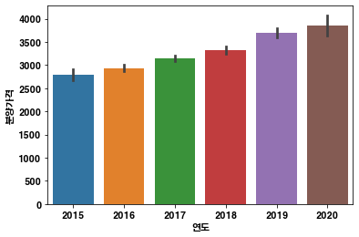

```python
sns.barplot(data=df, x='연도', y='분양가격')
```

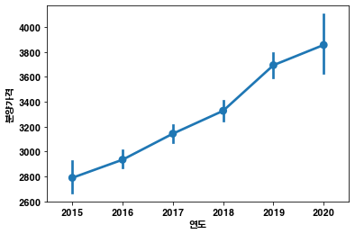

```python
sns.pointplot(data=df, x='연도', y='분양가격')
```

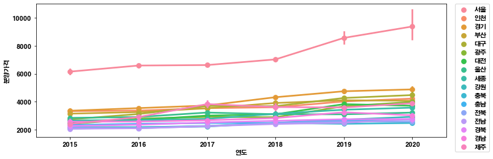

```python
plt.figure(figsize=(12, 4))
sns.pointplot(data=df, x='연도', y='분양가격', hue='지역명')
plt.legend(bbox_to_anchor=(1.02, 1), loc=2, borderaxespad=0.)
```

## 서울만 barplot으로 그리기

```
(270, 5)
```

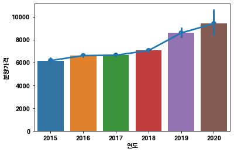

```python
df_seoul = df[df["지역명"] == '서울'].copy()
print(df_seoul.shape)

sns.barplot(data=df_seoul, x='연도', y='분양가격')
sns.pointplot(data=df_seoul, x='연도', y='분양가격')
```

## 연도별 분양가격 boxplot 그리기

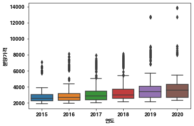

```python
sns.boxplot(data=df, x='연도', y='분양가격')
```

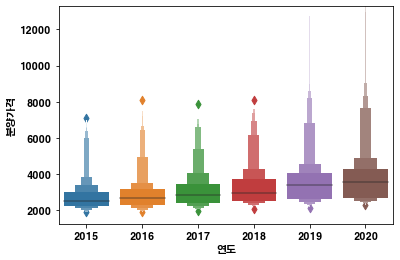

```python
sns.boxenplot(data=df, x='연도', y='분양가격')
```

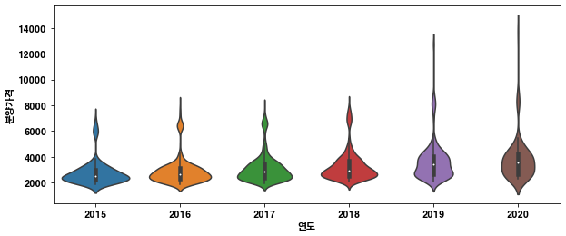

```python
plt.figure(figsize=(10, 4))
sns.violinplot(data=df, x='연도', y='분양가격')
```

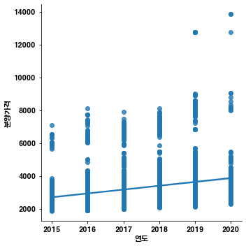

```python
sns.lmplot(data=df, x='연도', y='분양가격')
```

## 연도별 분양가격 swarmplot 그리기

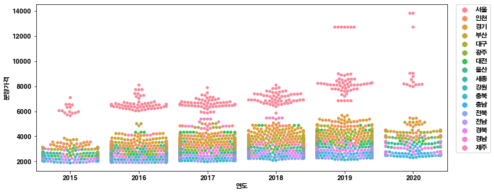

```python
plt.figure(figsize=(12, 5))
sns.swarmplot(data=df, x='연도', y='분양가격', hue='지역명')
plt.legend(bbox_to_anchor=(1.02, 1), loc=2, borderaxespad=0.)
```

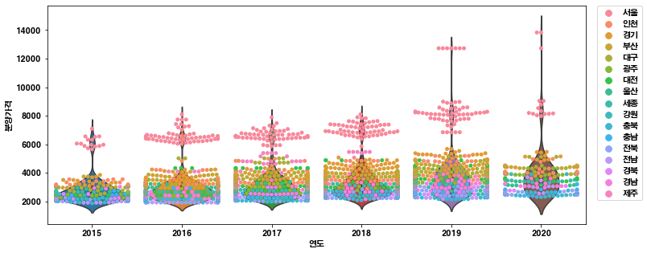

```python
plt.figure(figsize=(12, 5))
sns.violinplot(data=df, x='연도', y='분양가격')
sns.swarmplot(data=df, x='연도', y='분양가격', hue='지역명')
plt.legend(bbox_to_anchor=(1.02, 1), loc=2, borderaxespad=0.)
```

## 지역별 분양가격

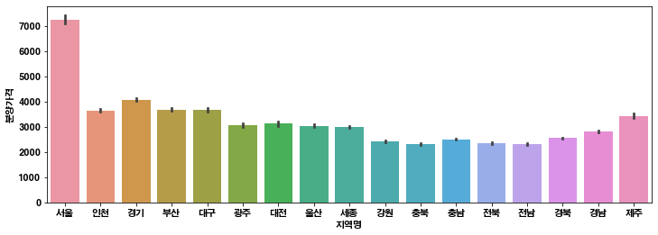

```python
# barplot으로 지역별 분양가격 그리기
plt.figure(figsize=(12, 4))
sns.barplot(data=df, x='지역명', y='분양가격')
```

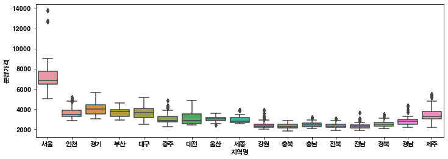

```python
# boxplot으로 지역별 분양가격 그리기
plt.figure(figsize=(12, 4))
sns.boxplot(data=df, x='지역명', y='분양가격')
```

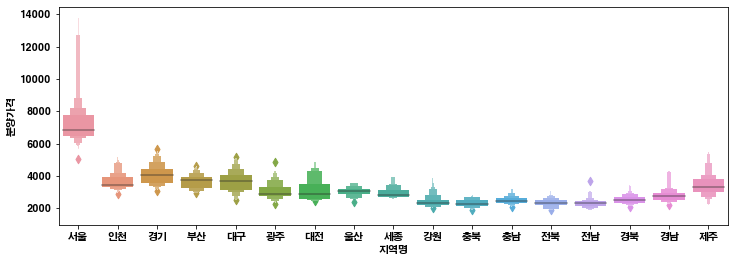

```python
plt.figure(figsize=(12, 4))
sns.boxenplot(data=df, x='지역명', y='분양가격')
```

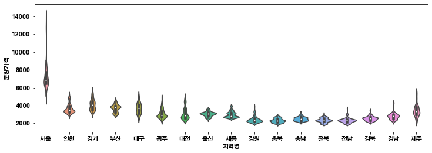

```python
# violinplot으로 지역별 분양가격 그리기
plt.figure(figsize=(12, 4))
sns.violinplot(data=df, x='지역명', y='분양가격')
```

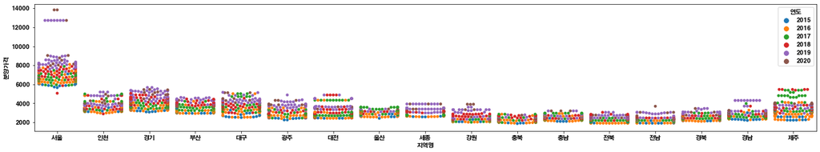

```python
# swarmplot으로 지역별 분양가격 그리기
plt.figure(figsize=(24, 4))
sns.swarmplot(data=df, x='지역명', y='분양가격', hue='연도')
```

**어려웠던 부분은 서칭을 통해 해결할 수 있었으며 이번 과제를 통해 데이터 분석의 재미를 한 층 더 깊게 알아갈 수 있었다.**